# Lab 07

Sonja

20/10/2021

### Learning objectives, technical skills and concepts:

- Bootstrap
- Apply functions
- Building custom functions
- Resampling

Worked with:

Aliza, Abby, Justin

Calculate a parametric 95% CI for mean bill length (in mm) for the Gentoo penguins in the penguins dataset from package palmerpenguins using your SSE function. For this calculation you should use Student’s t-distribution to calculate the critical values. Q1-Q5

#### Q1

What is the sample size, n? Show the code you used for the calculation and remember to check for missing data.

```r
n = length(dg)
n
```

```
## [1] 123
```

```r
na.x<-is.na(dat_gen$bill_length_mm)
          dg<- dat_gen$bill_length_mm[!na.x]
```

#### Q2

What is the sample standard deviation? Show the code you used for the calculation.

```r
sd.gen=sd(dg)
sd.gen
```

```
## [1] 3.081857
```

#### Q3

What are the critical t-values? Show the R code you used for the calculation.

```r
alpha=0.05
tcrit=qt(alpha/2, 122, lower.tail=FALSE)
tcrit
```

```
## [1] 1.9796
```

```r
-tcrit
```

```
## [1] -1.9796
```

#### Q4

What is the sample standard error? Show the R code you used for the calculation.

```r
sse_mean = function(x)
    { na.x<-is.na(x)
          x2<- x[!na.x]
                 sd.x2=sd(x2)
                  n=length(x2)
        sd.x2/(sqrt(n))
}

ssedg=sse_mean(dg)
ssedg
```

```
## [1] 0.2778817
```

#### Q5

Finally, construct the CI and show the R code you used for the calculation.

Multiply the sample standard error by the critical t-value. This is the radius of the CI. Express the CI as mean±radius

```r
#mean
mean.x=mean(dg)
#radius
radius=tcrit*ssedg

#CI upper & lower
mean.x+radius
```

```
## [1] 48.05497
```

```r
mean.x-radius
```

```
## [1] 46.95478
```

$47.5\pm 0.5501$

Calculate a bootstrap 95% CI for mean bill length (in mm) for the Gentoo penguins in penguins dataset from package palmerpenguins. Use the boot() function from package boot()

```r
boot_mean = function(x, i)
{
  return(mean(x[i], na.rm = TRUE))
}
```

```r
myboot =
  boot(
    data = dg,
    statistic = boot_mean,
    R = 10000)
print(myboot)
```

```
##
## ORDINARY NONPARAMETRIC BOOTSTRAP
##
##
## Call:
## boot(data = dg, statistic = boot_mean, R = 10000)
##
##
## Bootstrap Statistics :
##     original       bias    std. error
## t1* 47.50488 -0.003551382   0.2797563
```

#### Q7

Show the r code you used to call the boot() function.

```r
require(boot)
```

#### Q8

Show the r code you used to calculate the upper and lower 2.5% quantiles.

```r
quantile(
  myboot$t,
  c(0.025, 0.975))
```

```
##     2.5%    97.5%
## 46.95772 48.05693
```

#### Q9

Show your completed rarefaction_sampler() function.

```r
rarefaction_sampler = function(input_dat, n_iterations)
{
 n_input_rows = nrow(input_dat)

  results_out = matrix(
    nrow = n_iterations,
    ncol = n_input_rows)

  # The outer loop: runs once for each bootstrap iteration.  index variable is i
  for(i in 1:n_iterations)
  {
    # The inner loop: simulates increasing sampling intensity
    # Sampling intensity ranges from 1 site to the complete count of
    # sites in the input data (n)
    for(j in 1: n_input_rows)
    {
      # sample the input data row indices, with replacement
      rows_j = sample(n_input_rows, size = j, replace=TRUE)

      # Creates a new data matrix
      t1 = input_dat[rows_j, ]

      # Calculates the column sums
      t2 = apply(t1, 2, sum)

      # Counts the number of columns in which any moths were observed
      results_out[i, j] = sum(t2 > 0)
    }
  }
  return(results_out)
}

rarefact = rarefaction_sampler(moths, 100)
head(rarefact)
```

```
##      [,1] [,2] [,3] [,4] [,5] [,6] [,7] [,8] [,9] [,10] [,11] [,12] [,13] [,14]
## [1,]    3    7   10   10   11    9   11   10    9    11    11    10    11    11
## [2,]    3    6    6    8   10   11   10   10    9    11    10    11    10    11
## [3,]    5   10    9    7   11   11   11   11   10    11    11    11    11    11
## [4,]    4    6    8   11    9   10    9   10   11    11    11    11    11    11
## [5,]    6   10    8   10   11   11   11   10   11    11    11    11    11    11
## [6,]    4    6    7    9    9    9   10   10   11    11    11    11    11    11
##      [,15] [,16] [,17] [,18] [,19] [,20] [,21] [,22] [,23] [,24]
## [1,]    11    11    11    10    11    11    11    11    11    11
## [2,]    11    11    11    11    11    11    11    11    11    11
## [3,]    11    11    11    11    11    11    11    11    11    11
## [4,]    11    11    11    11    11    11    11    11    11    11
## [5,]    11    11    11    11    11    11    11    11    11    11
## [6,]    11    11    10    11    11    11    11    11    11    11
```

#### Q10:

What did you find most difficult about building the function? I do think that I actually built the formula, but I had to edit parts of the formula. I think it was challenging connecting the function loop variables to the other loops. I really did not understand what the point of the challenge was.

#### Q11

Show the code you used to perform the simulations and construct the curve

```r
rarefact = rarefaction_sampler(moths[,-1], 10000)
```

```r
rare_mean = apply(rarefact, 2, mean)
rare_quant = apply(rarefact, 2, quantile, probs=c(0.025, 0.975))
rare = t(rbind(rare_mean, rare_quant))
```

#### Q12

Include your rarefaction curve plot in your report. Show the R-code you used to create your plot.

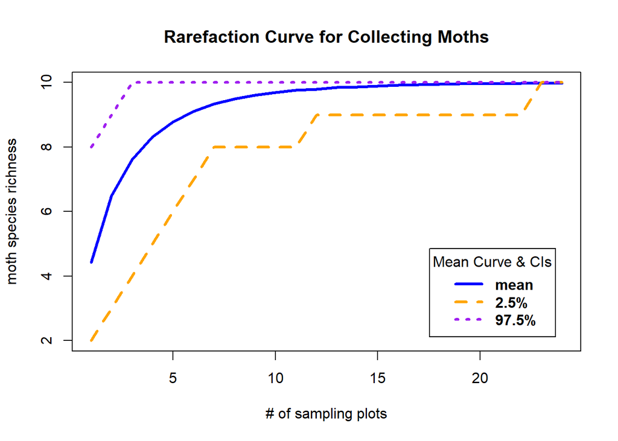

```r
matplot(
  rare,
  type='l',
  lwd=3,
  xlab='# of sampling plots',
  ylab='moth species richness',
  main='Rarefaction Curve for Collecting Moths', col=c("blue","orange","purple"))

legend(
  'bottomright',
  legend=c('mean','2.5%','97.5%'),
  lty=c(1,2,3),  lwd=3, col=c("blue","orange","purple"), inset=c(.05,.05), title="Mean Curve & CIs",text.font=2)
```

#### Q13

About how many sites should you visit if you want to see all of the moth species? Explain your reasoning using your rarefaction curve figure.